Ejercicio: geyser

Considere el conjunto de datos geyser de la libreria MASS. Haga un análisis del dataset.

1- Ajustar un modelo mixto con dos normales multivaridas: mod1.

```r
library(mclust)
library(MASS)
```

```r
gmm=Mclust(geyser, G = 2) #solo estima la cantidad de correcta de clusters
```

```r
summary(gmm, parameters=T)
```

```
## ----------------------------------------------------
## Gaussian finite mixture model fitted by EM algorithm
## ----------------------------------------------------
##
## Mclust VEE (ellipsoidal, equal shape and orientation) model with 2 components:
##
##  log-likelihood   n df       BIC       ICL
##       -1404.345 299  9 -2859.995 -2860.404
##
## Clustering table:
##   1   2
## 198 101
##
## Mixing probabilities:
##         1         2
## 0.6618167 0.3381833
##
## Means:
##               [,1]      [,2]
## waiting  66.789445 83.126549
## duration  4.234303  1.947114
##
## Variances:
## [,,1]
##            waiting   duration
## waiting  169.68601 -2.1103298
## duration  -2.11033  0.1838441
## [,,2]
##             waiting    duration
## waiting  48.8362912 -0.60736109
## duration -0.6073611  0.05291104
```

2- Utilize el criterio BIC para seleccionar el mejor modelo: mod2.

```r
best_gmm = Mclust(geyser) #Solo estima la mejor cantidad de cluster a partir del BIC
```

```r
BIC = mclustBIC(geyser)
BIC
```

```
## Bayesian Information Criterion (BIC):
##         EII       VII       EEI       VEI       EVI       VVI       EEE
## 1 -4448.623 -4448.623 -3373.789 -3373.789 -3373.789 -3373.789 -3218.907
## 2 -3917.918 -3912.518 -2944.754 -2896.177 -2934.590 -2897.029 -2913.051
## 3 -3770.522 -3763.184 -2800.650 -2811.765 -2807.193 -2818.493 -2806.267
## 4 -3655.390 -3675.055 -2816.742 -2804.658 -2789.326 -2768.568 -2822.402
## 5 -3595.073 -3619.212 -2830.031 -2823.442 -2808.885 -2791.857 -2835.685
## 6 -3511.295 -3505.618 -2840.448 -2805.442 -2810.982 -2802.817 -2842.825
## 7 -3467.115 -3492.205 -2834.906 -2810.509 -2806.854 -2822.737 -2816.759
## 8 -3466.336 -3479.665 -2851.950 -2825.215 -2826.639 -2847.737 -2813.116
## 9 -3458.921 -3433.104 -2838.921        NA -2834.797        NA -2819.878
##         VEE       EVE       VVE       EEV       VEV       EVV       VVV
## 1 -3218.907 -3218.907 -3218.907 -3218.907 -3218.907 -3218.907 -3218.907
## 2 -2859.995 -2900.474 -2865.101 -2916.377 -2860.004 -2905.128 -2864.570
## 3 -2817.408 -2812.624 -2818.174 -2817.146 -2828.175 -2823.611 -2826.782
## 4 -2810.239 -2794.489 -2771.983 -2839.086 -2825.345 -2807.376 -2786.694
## 5 -2828.241 -2813.310 -2793.504 -2842.223 -2849.978 -2810.878 -2815.703
## 6 -2805.277 -2814.605 -2807.203 -2868.080 -2824.618 -2828.091 -2825.125
## 7 -2810.371 -2837.510 -2822.113 -2829.676 -2828.840 -2831.708 -2855.563
## 8 -2825.195 -2830.164 -2865.761 -2852.065 -2852.250 -2849.150 -2878.871
## 9 -2837.956 -2837.630 -2895.068 -2829.249 -2865.500 -2874.741 -2903.711
##
## Top 3 models based on the BIC criterion:
##     VVI,4     VVE,4     VVV,4
## -2768.568 -2771.983 -2786.694
```

```r
# summary(bic)
```

3- Compare mod1 con mod2.

```r
densidad=densityMclust(geyser, G=2)
```

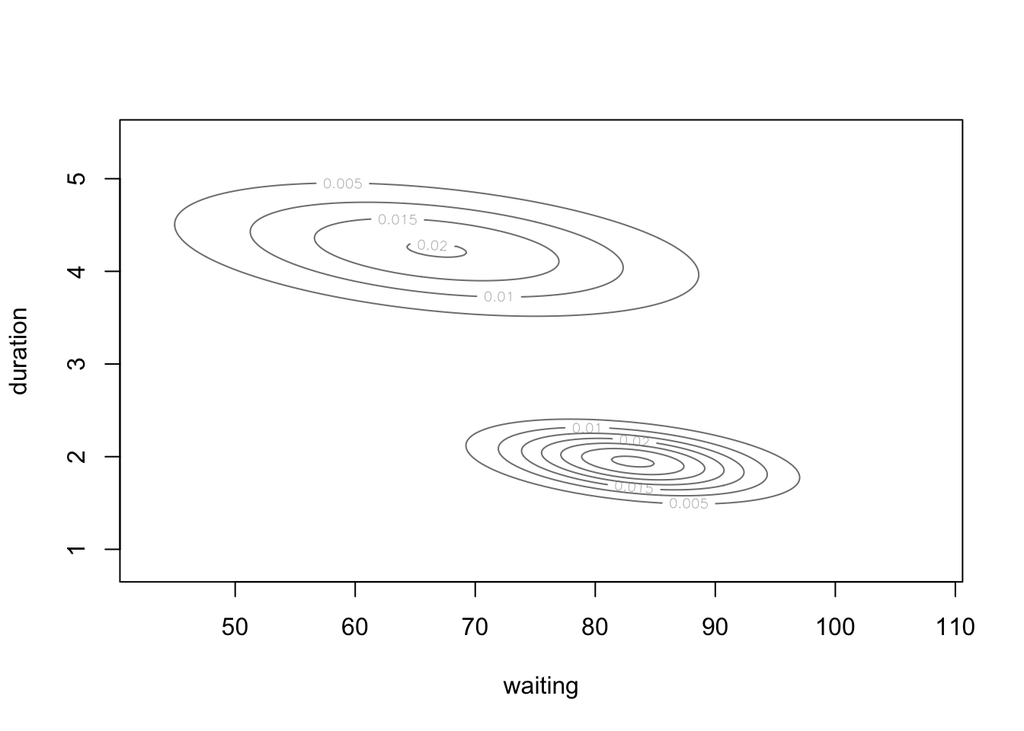

```r
summary(mclustBIC(geyser, G=2))
```

```
## Best BIC values:
##              VEE,2         VEV,2        VVV,2
## BIC      -2859.995 -2.860004e+03 -2864.570083
## BIC diff     0.000 -9.452906e-03    -4.575443
```

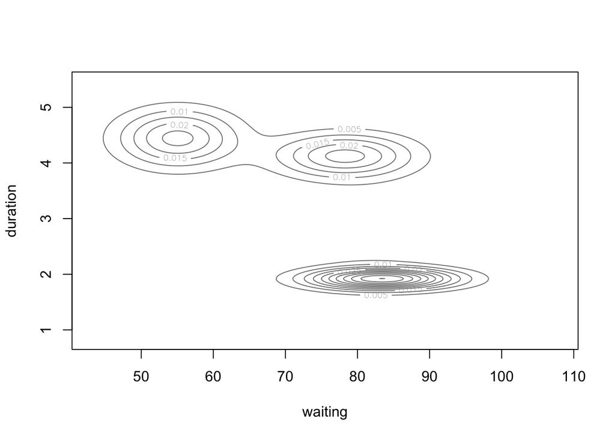

```r
# Ploteamos la funcion de densidad de las gauseanas multivariadas estimadas con
# las que clusterizo los datos
densidad_best_gmm=densityMclust(geyser)
```

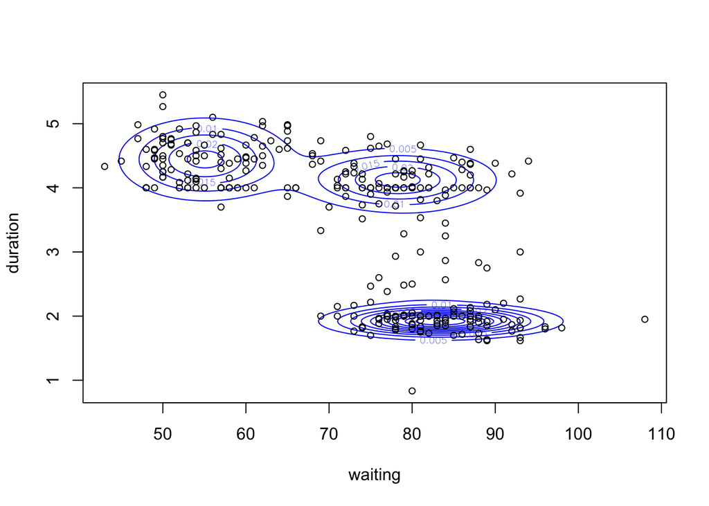

```r
plot(densidad_best_gmm, what="density", data=geyser, col = "blue")
```

```r
summary(mclustBIC(geyser))
```

```
## Best BIC values:
##              VVI,4        VVE,4       VVV,4
## BIC      -2768.568 -2771.983116 -2786.69437
## BIC diff     0.000    -3.415251   -18.12651
```

4- ¿Hay algunos puntos para los cuales no este clara la clasificación?¿Qué puede decir sobre ellos?

```r
geyser_2 = geyser
geyser_2["cluster"]=best_gmm$classification
geyser_2["probabilidad_clasificacion"]=best_gmm$uncertainty
geyser_2
```

```
##     waiting  duration cluster probabilidad_clasificacion
## 1        80 4.0166667       1               1.201029e-02
## 2        71 2.1500000       4               2.006023e-01
## 3        57 4.0000000       3               8.985520e-03
## 4        80 4.0000000       1               1.301567e-02
## 5        75 4.0000000       1               8.696920e-03
## 6        77 2.0000000       4               5.566359e-02
## 7        60 4.3833333       3               1.657144e-02
## 8        86 4.2833333       1               8.051763e-03
## 9        77 2.0333333       4               6.947981e-02
## 10       56 4.8333333       3               1.424344e-04
## 11       81 1.8333333       4               4.146941e-02
## 12       50 5.4500000       3               2.782648e-08
## 13       89 1.6166667       4               1.690107e-01
## 14       54 4.8666667       3               3.691906e-05
```

[output cut: 285 more lines]

```r
# Outlier
# Aqui observamos que la observacion que se aprecia mas alejada, tiene un valor de
# probabilidad de pertenecer al cluster 4, bajo. Lo cual es logico.
geyser[geyser["waiting"]==108,]
```

```
##    waiting duration
## 61     108     1.95
```

5- Explore el paquete mclust o el que quiera utilizar y uselo en el dataset geyser.

Ejercicio: hacking mixture models

1- Genere un conjunto de datos univariados con una distribución que no sea normal y observe los resultados. (Sugerencia: utilizar una distribución asimétrica)

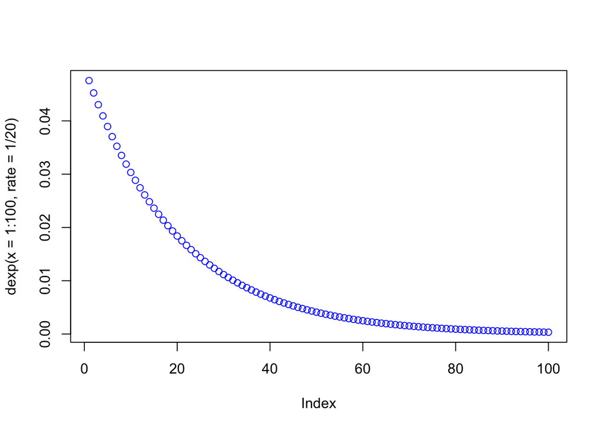

```r
plot(dexp(x = 1:100,rate = 1/20), col = "blue")
```

```r
x1 = rexp(rate = 1/20, n = 50)
x2 = rexp(rate = 1/10, n = 50)
x3 = rexp(rate = 1/20, n = 50)
x4 = rexp(rate = 1/10, n = 50)

data = data.frame(rbind(cbind(x1,x2),cbind(x3,x4)))

gmm_no_gaussean=Mclust(data)

densidad_gmm_no_gaussean=densityMclust(data)
```

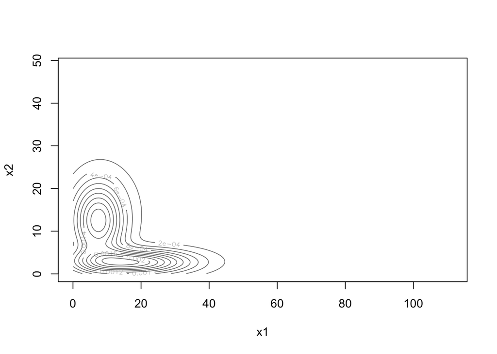

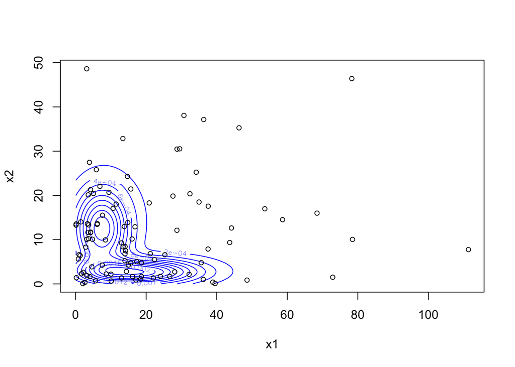

```r
plot(densidad_gmm_no_gaussean, what="density", data=data, col = "blue")
```

Observamos como el supuesto de normalidad de los regresores es muy fuerte.

2- ¿Qué tan sensible es la estimación de parámetros del modelo mixto a la presencia de valores atípicos?

```r
geyser_outliers=geyser
geyser_outliers[5,"waiting"]=150
geyser_outliers[7,"waiting"]=150

# geyser_outliers[5,"duration"]=50
# geyser_outliers[8,"duration"]=40

densidad_outliers_gmm=densityMclust(geyser_outliers)
```

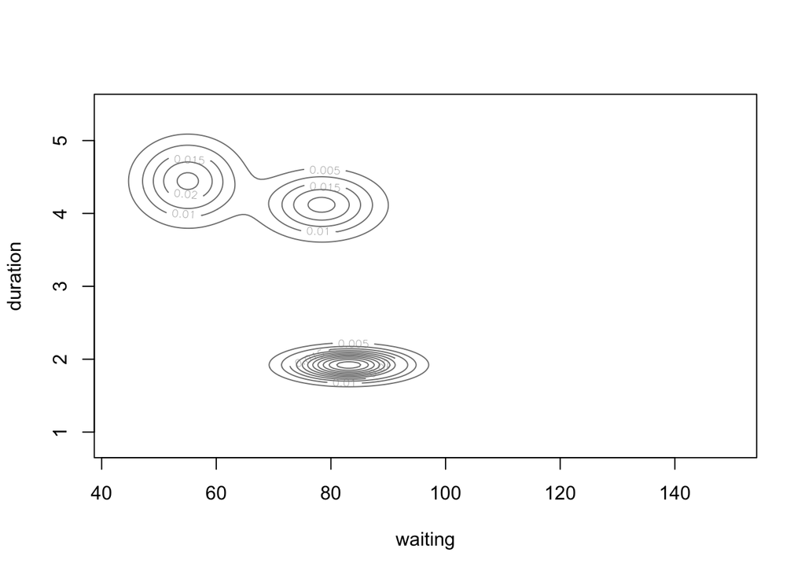

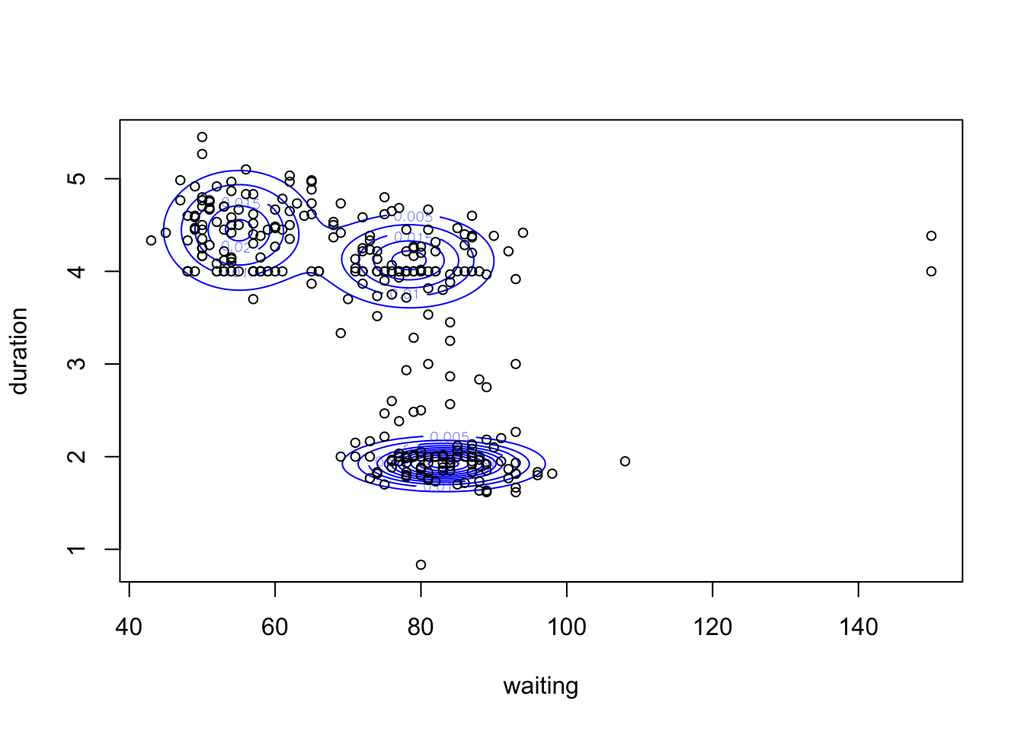

```r
outliers_gmm = Mclust(geyser_outliers)
plot(densidad_outliers_gmm, what="density", data=geyser_outliers, col = "blue")
```

```r
outliers_gmm$G # Ver coloreando clusters, a ver que hace con los outliers
```

```
## [1] 4
```

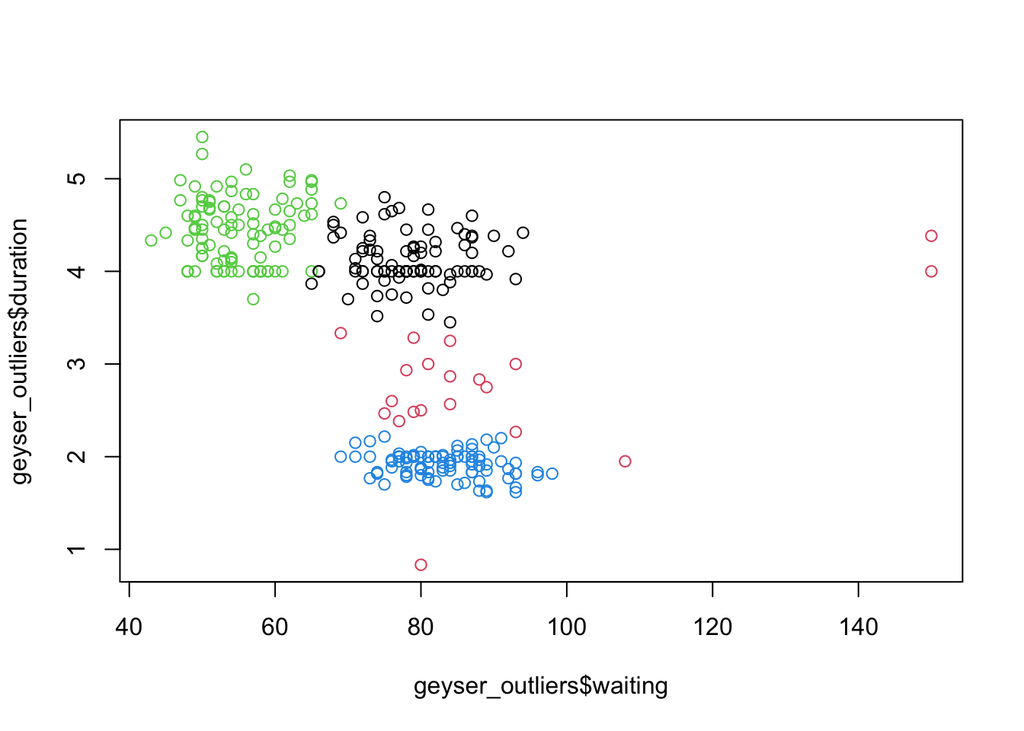

```r
geyser_outliers["clusters"] = outliers_gmm$classification

plot(x =geyser_outliers$waiting , y = geyser_outliers$duration, col = geyser_outliers$clusters)
```

```r
geyser_outliers=geyser
geyser_outliers[5,"waiting"]=150
geyser_outliers[7,"waiting"]=150

geyser_outliers[5,"duration"]=50
geyser_outliers[8,"duration"]=40

densidad_outliers_gmm=densityMclust(geyser_outliers)
```

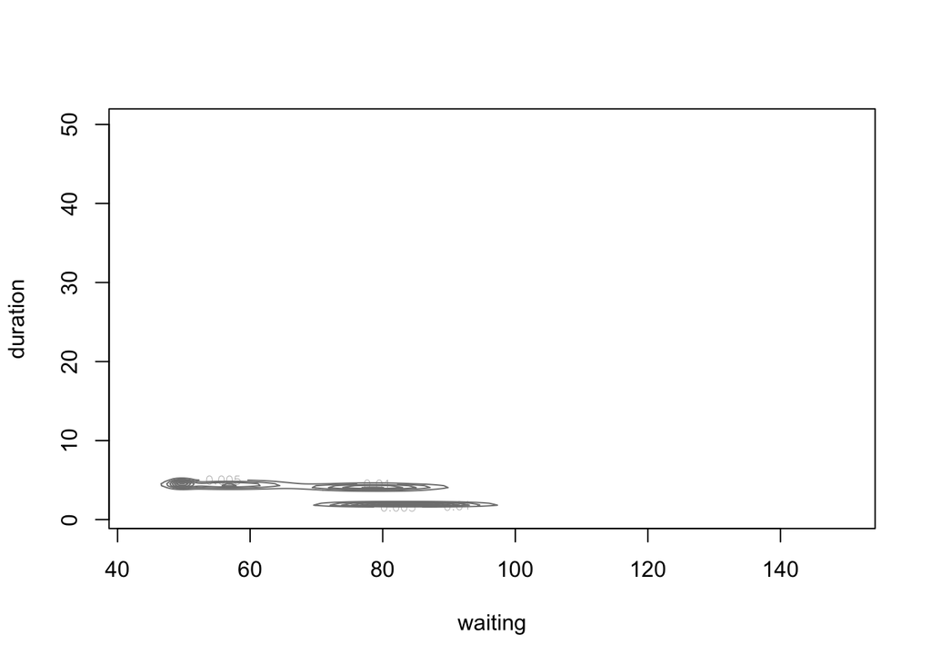

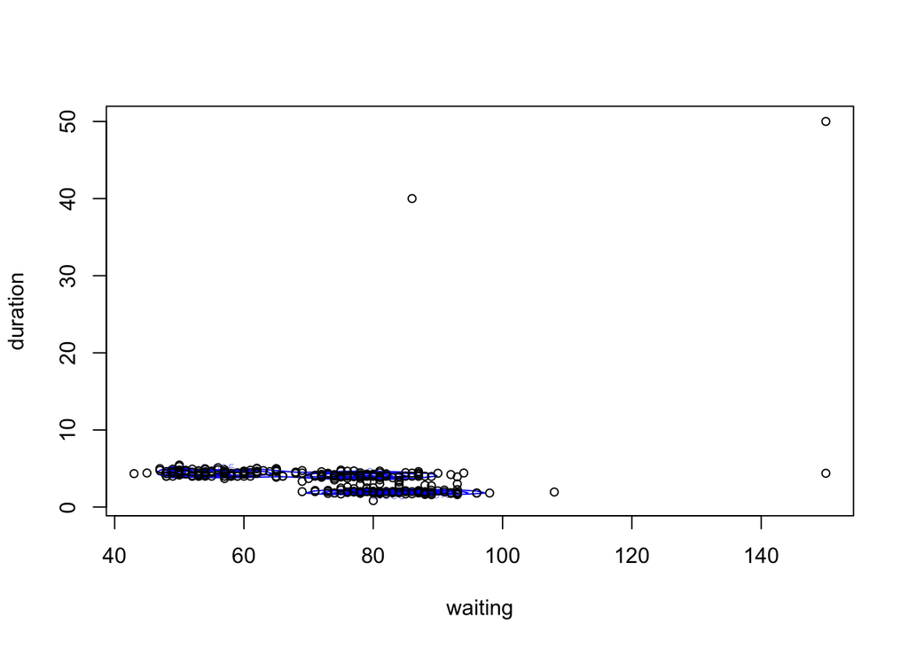

```r
plot(densidad_outliers_gmm, what="density", data=geyser_outliers, col = "blue")
```

```r
outliers_gmm$G # Ver coloreando clusters, a ver que hace con los outliers
```

```
## [1] 4
```

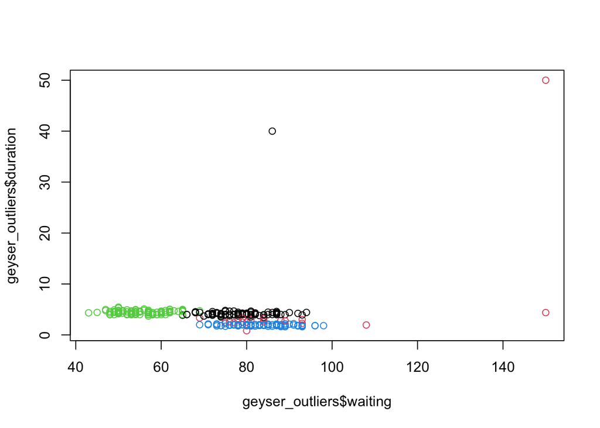

```r
geyser_outliers["clusters"] = outliers_gmm$classification
plot(x =geyser_outliers$waiting , y = geyser_outliers$duration, col = geyser_outliers$clusters)
```

```r
geyser_outliers=geyser
geyser_outliers[5,"waiting"]=150
geyser_outliers[5,"duration"]=50

geyser_outliers[7,"waiting"]=150
geyser_outliers[7,"duration"]=51.3

geyser_outliers[9,"waiting"]=149.5
geyser_outliers[9,"duration"]=49.2

geyser_outliers[11,"waiting"]=148
geyser_outliers[11,"duration"]=52

geyser_outliers[13,"waiting"]=147.3
geyser_outliers[13,"duration"]=51.87

geyser_outliers[22,"waiting"]=147.1
geyser_outliers[22,"duration"]=52.7

geyser_outliers[23,"waiting"]=148.5
geyser_outliers[23,"duration"]=52.2

densidad_outliers_gmm=densityMclust(geyser_outliers)
```

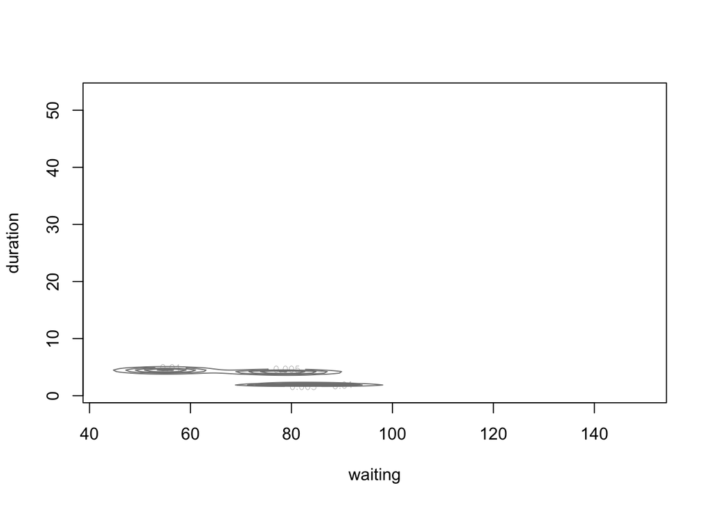

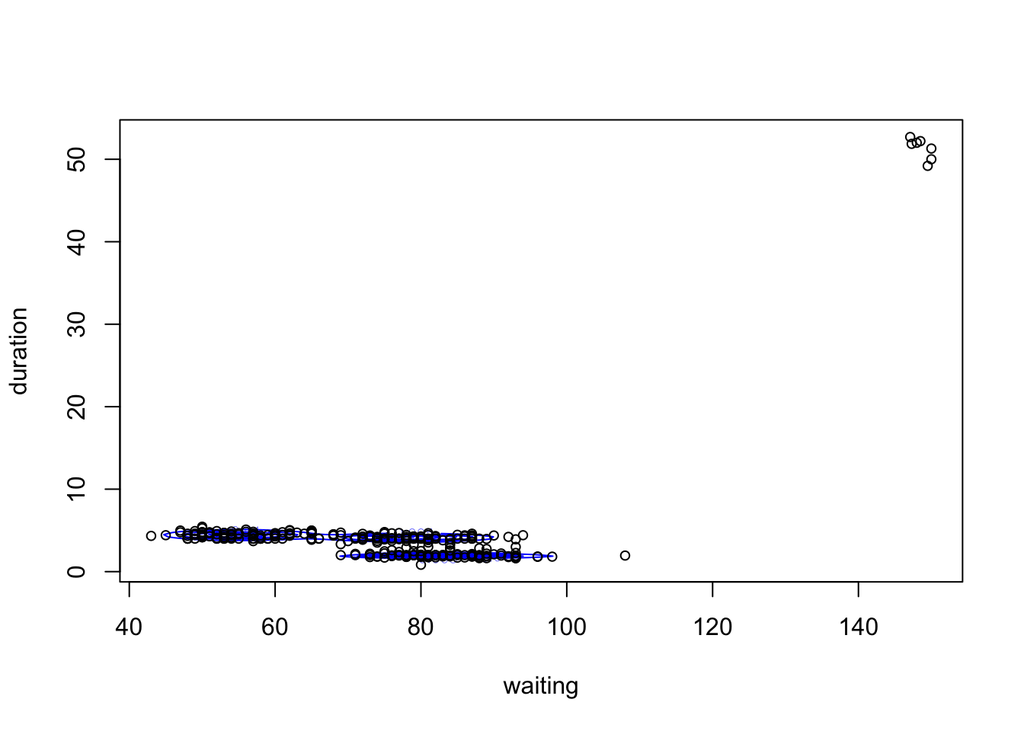

```r
plot(densidad_outliers_gmm, what="density", data=geyser_outliers, col = "blue")
```

```r
Mclust(geyser_outliers)$G
```

```
## [1] 5
```

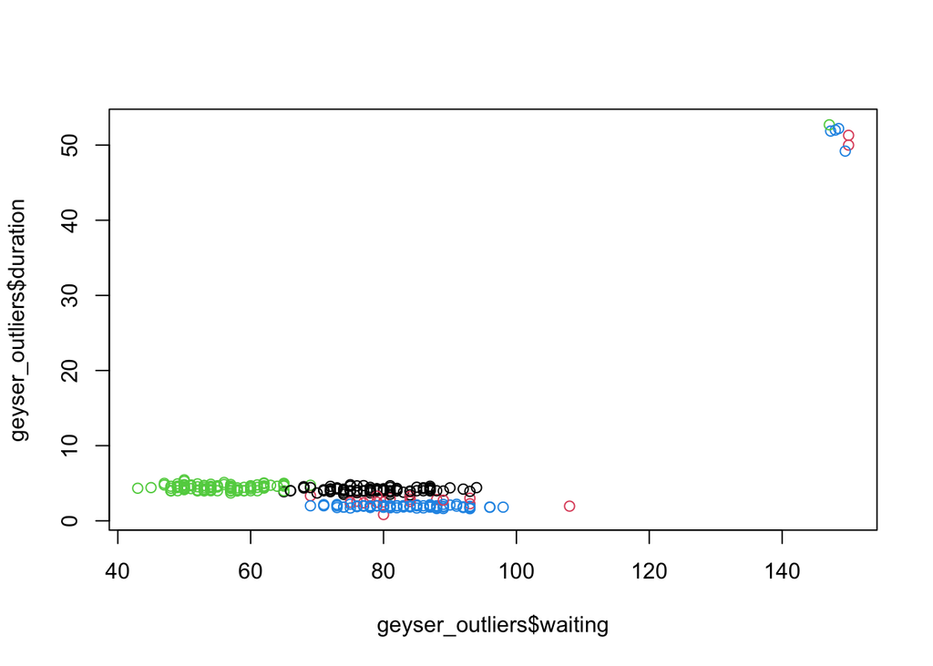

```r
geyser_outliers["clusters"] = outliers_gmm$classification
plot(x =geyser_outliers$waiting , y = geyser_outliers$duration, col = geyser_outliers$clusters)
```

```r
# Observamos la certeza o seguridad con la que clasifico a los outliers en sus clusters
outliers_gmm$uncertainty[c(5, 7, 9, 11, 13, 22, 23)]
```

```
##            5            7            9           11           13           22
## 0.0000000000 0.0000000000 0.0160176843 0.0076400423 0.0832810122 0.0008549918
##           23
## 0.0095566010
```

3- ¿Qué sucede cuando la dimensión de los datos es mucho mayor a la cantidad de observaciones?

```r
rows = sample(x = 1:300,20)
geyser_alta_dimension=geyser[rows,c("waiting","duration")]

mu1 = mean(geyser_alta_dimension$waiting)
tita1 = sd(geyser_alta_dimension$waiting)

mu2 = mean(geyser_alta_dimension$duration)
tita2 = sd(geyser_alta_dimension$duration)

new_waiting = replicate(200,rnorm(n = 20, mean = mu1, sd = tita1) + runif(1, min=50, max=100))
new_duration = replicate(200,rnorm(n = 20, mean = mu2, sd = tita2) + runif(1, min=1, max=4))


data_alta_dimension = data.frame(cbind(geyser_alta_dimension,new_waiting,new_duration))
data_alta_dimension
```

```
##     waiting duration       X1       X2       X3       X4       X5       X6
## 232      53 4.216667 165.6257 147.8304 142.4012 148.1191 149.0766 121.6086
## 285      66 4.000000 200.7541 172.8033 147.7342 162.4792 146.8786 135.0534
## 103      51 4.283333 173.4442 168.2986 156.2415 144.2765 150.9443 151.9564
## 82       74 1.816667 154.6115 184.9880 158.9907 164.6635 153.0153 156.7277
## 247      79 3.283333 155.0510 136.7397 142.1874 155.1553 158.4563 109.3141
## 161      75 4.800000 146.1981 124.8858 170.2552 152.6246 154.4347 131.2443
## 73       54 4.150000 173.8948 156.5690 145.0149 160.1901 161.3701 126.6163
## 221      93 1.933333 151.0200 156.6439 156.5966 183.6128 134.7740 135.1972
## 180      87 4.366667 182.8976 162.5348 155.8164 137.8642 162.8905 140.2691
## 144      77 4.000000 145.6544 161.6425 157.2077 156.3165 143.4529 114.7690
## 52       60 4.000000 153.1965 152.6301 144.8325 161.0387 133.1548 112.8005
## 237      87 4.383333 136.2640 136.9172 153.2543 158.6943 129.6570 127.5839
## 271      63 4.733333 136.6050 146.9521 159.0585 143.1663 141.1853 135.7279
## 33       75 2.216667 151.9241 168.8498 149.9717 155.8192 147.2579 119.3587
```

[output cut: 1056 more lines]

```r
# densidad_alta_dimension_gmm=densityMclust(data_alta_dimension)
# plot(densidad_alta_dimension_gmm, what="density", data=data_alta_dimension, col = "blue")
```

```r
gmm_alta_dimensionalidad=Mclust(data_alta_dimension)
```

```r
gmm_alta_dimensionalidad$G
```

```
## [1] 1
```

```r
gmm_alta_dimensionalidad$classification
```

```
##  [1] 1 1 1 1 1 1 1 1 1 1 1 1 1 1 1 1 1 1 1 1
```

Vemos que falla en la asignacion de clusters, da resultados raros y/o erroneos.